# Basic R Course - 19 Repreducible research

## 19.1 Markdown

- R Markdown is a format for writing with R
- Use it to **embed R code and results** into slideshows, pdfs, html documents, Word files and more

## 19.2 Markdown (cont’d)

- In **Rstudio**
  - File $\rightarrow$ New File $\rightarrow$ R Markdown…
  - Insert title and author
  - Select format

# 20 Markdown basics

## 20.1 Headers

### Code

```markdown
# Gobo
## Mokey
```

## 20.2 Emphasis

### Code

```markdown
*Methods*
_Methods_
**Methods**
__Methods__
```

### output

*Methods*  
*Methods*  
**Methods**  
**Methods**

## 20.3 Bullets

### Code

```markdown
* Method 1
- Method 2
+ Method 3

* Results
  * Method 1
  * Method 2
```

## 20.4 Links

### Code

```markdown
[link](http://example.com)
```

### output

[link](http://example.com)

## 20.5 Images

### Code

```markdown
![Rsymbol](https://upload.wikimedia.org/
                wikipedia/commons/1/12/
                R_logo_2000.png)
```

### output

[figure not shown]

Rsymbol

## 20.6 Escaping

### Code

```markdown
\*Method\*
```

### Output

*Method*

## 20.7 Code

### Code

```markdown
`Methods`
```

### Output

`Methods`

Escaping Markdown characters with a back-slash allows you to use any characters which might be getting accidentally converted into HTML

# 21 Code chunks

## 21.1 Code chunks

- **Rmarkdown** and **Quarto** allow us to include code blocks
- They will be executed during rendering

### Code

````r
```
1+1
```
````

### Output

```r
1+1
```

```
[1] 2
```

## 21.2 Plots

- Including plots works the same way

### Code

````r
```

plot(x=c(1, 2),
     y=c(1, 2))

```
````

### Output

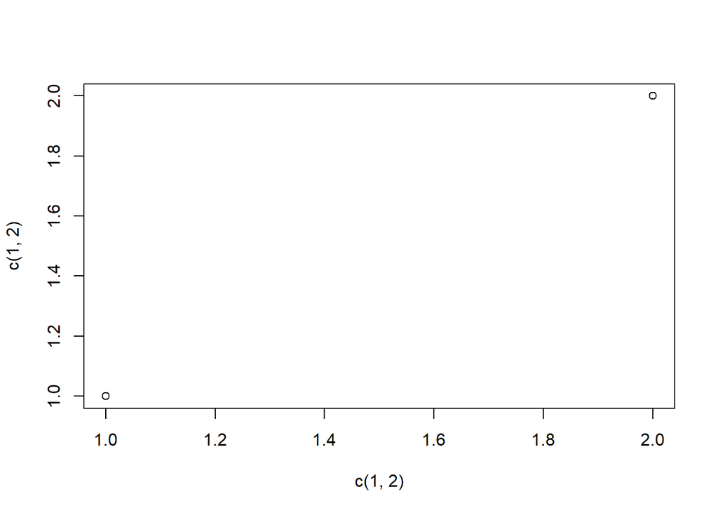

```r
plot(x=c(1, 2),
     y=c(1, 2))
```

## 21.3 Chunk options

- **eval**: If `FALSE`, knitr will not run the code in the code chunk
- **include**: If `FALSE`, knitr will run the chunk but not include the chunk in the final document
- **echo**: If `FALSE`, knitr will not display the code in the code chunk above it’s results in the final document
- **results**: If `hide`, knitr will not display the codes results in the final document. If `hold`, knitr will delay displaying all output until the end of the chunk. If ``asis`, knitr will pass through results without reformatting them (useful if results return raw HTML, etc.)

## 21.4 Chunk options (cont’d)

- **error**: If `FALSE`, knitr will not display any error messages generated by the code
- **message**: If `FALSE`, knitr will not display any messages
- **warning**: If `FALSE`, knitr will not display any warning messages
- **cache**: If `TRUE`, knitr will cache the results to reuse in future knits. Knitr will reuse the results until the code chunk is altered.
- **cache.comments**: If `FALSE`, knitr will not rerun the chunk if only a code comment has changed

## 21.5 Chunk options (cont’d)

- **fig.cap**: A character string to be used as a figure caption in LaTex
- **fig.height**, **fig.width**: The width and height to use in R for plots created by the chunk (in inches)

# 22 Version Control with Git

## 22.1 What is Git and why use it?

- Git is software for (version control)
- This means Git keeps track of the different versions of your code
- Helps you answer questions as:
  - Which file should I look at to see the changes made last week?
  - What has changed between November and now?
  - What was the version of the manuscript that we submitted?

## 22.2 Old fashioned version control

```bash
        analysis.sps
        analysis1.sps
        analysisFinal.sps
        analysisFinal_long.sps
        analysisFinal_revision.sps
        analysisFinal_revisionnew.sps
        analysis2.sps
```

- However it is not always clear to other people
- And probably not even to your future self

## 22.4 Git workflow

[figure not shown]

## 22.6 Git in RStudio

# 23 Shiny

## 23.2 Shiny in Rstudio

- File $\rightarrow$ New File $\rightarrow$ Shiny Web App…
- Insert application name
- Let’s try an example

## 23.3 Structure

- Shiny applications consist of:
  - a user interface object (ui): layout and appearance of your app
  - a server function: instructions that your computer needs to build your app
  - a call to the shinyApp function: creates Shiny app objects

## 23.4 Structure in code

```r
library(shiny)

# Define UI ----
 ui <- fluidPage(
)

# Define server logic ----
 server <- function(input, output) {
}

# Run the app ----
shinyApp(ui = ui, server = server)
```